# La Política de la Corrupción

Sesión 10: China y Hong Kong — Crecimiento, gobierno limpio y campañas anticorrupción

Bogdan G. Popescu

bgpopescu@tec.mx

Tecnológico de Monterrey

## Qué pensar del trato de Diego

Cuatro escenas, y en ninguna aparece alguien con un maletín lleno de efectivo.

- Solo la ciudad podía vender ese suelo, así que el acceso valía algo desde el principio
- El precio fue una parte de las ganancias para el **hermano** del funcionario, no un sobre
- Las torres se construyeron y los empleos fueron reales
- Los mejores constructores nunca pudieron concursar, y la ciudad vendió barato

Nadie robó nada de forma directa, y la ciudad creció. Esa es la parte difícil.

**Hoy:** ¿pueden ir juntos la corrupción y el crecimiento, y quién paga el costo? Y luego: si un país quiere limpiar esto, ¿qué sí funciona?

# Parte I — El enigma: auge y sobornos

## El auge no está en duda

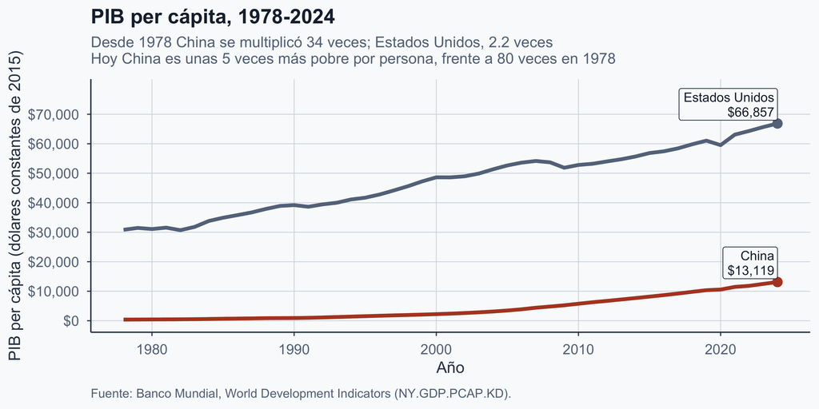

## Dos formas de comparar economías

Para comparar el PIB de dos países hay que ponerlos en la misma moneda — y hay dos maneras.

- **Tipo de cambio de mercado.** Se convierte el PIB chino a dólares al tipo de cambio del día: el precio al que de verdad se compran y venden las divisas.
- **Paridad de poder adquisitivo.** Se ajusta por lo que cuestan las cosas en cada país. Una comida o un corte de pelo cuestan menos en China, así que el mismo dinero alcanza para más — y su economía se ve más grande.

Ninguna está mal: la primera mide cuánto vale la producción china en los mercados mundiales; la segunda, cuánto alcanza para quienes viven allá.

## Alcanzando a EE. UU., según cómo se mida

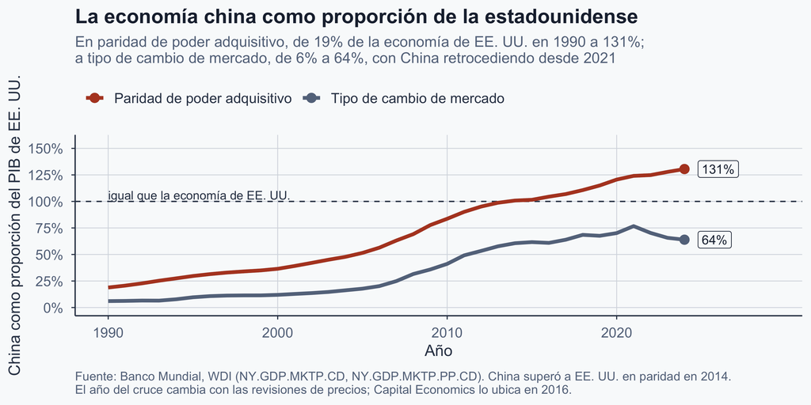

Por persona, China sigue siendo unas cinco veces más pobre. En tamaño total, o ya rebasó a Estados Unidos o es dos tercios de su economía. Nada de China cambia entre esas dos frases — solo el tipo de cambio que se usa para comparar.

## Qué le hace la corrupción al crecimiento

China logró todo eso durante décadas en que la corrupción era generalizada. Según el argumento estándar, no debería haber podido.

```
%%{init: {"fontSize": 22, "htmlLabels": false, "flowchart": {"useMaxWidth": true, "nodeSpacing": 45, "rankSpacing": 55, "htmlLabels": false, "padding": 14, "curve": "basis"}, "themeVariables": {"fontSize": "22px", "fontFamily": "DM Sans, Segoe UI, sans-serif", "primaryColor": "#eef2f5", "primaryText…
flowchart LR
  A["Los funcionarios<br/>pueden exigir<br/>sobornos"] --> B["Invertir cuesta<br/>más y es<br/>menos seguro"]
  A --> D["El dinero público<br/>se desvía"]
  B --> C["Las empresas invierten<br/>menos y siguen<br/>siendo pequeñas"]
  D --> E["Peores carreteras,<br/>escuelas<br/>y tribunales"]
  C --> F["Crecimiento<br/>más lento"]
  E --> F
  classDef bad fill:#f6e7df,stroke:#b44527,stroke-width:2px,color:#1e293b;
  class F bad;
```

Todas las flechas apuntan en la misma dirección: hacia abajo. Si esta fuera toda la historia, la ciudad de Diego se habría estancado — y no fue así.

Ilustración del autor sobre el argumento estándar. Sin unidades; solo conceptual.

## China hizo lo contrario

- De 1978 a 2010 la economía creció alrededor de 9% al año
- La corrupción no bajó conforme se profundizaron los mercados — cambió de forma
- Wedeman llama a esto la **doble paradoja** de China: el crecimiento y la corrupción subieron juntos

Así que, o el diagrama de la diapositiva anterior está mal, o le falta algo.

Fuente: Wedeman (2012), *Double Paradox*, cap. 1.

## La relación simple entre países es débil

Y China no es una excepción aislada.

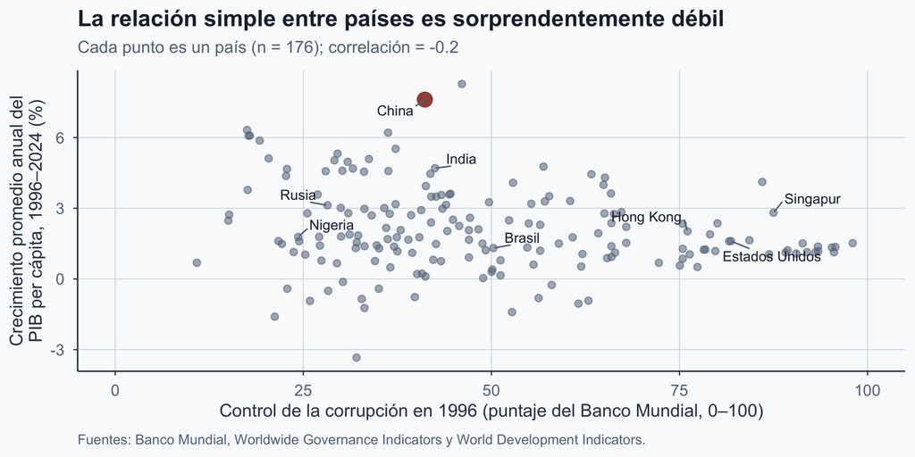

Solo descriptivo. No hay controles por ingreso inicial, región ni error de medición, y el año base es arbitrario. Esto motiva el enigma; no pone a prueba la hipótesis corrupción–crecimiento.

## ¿Y entonces?

> Contar la corrupción nos dice cuánta hay. No nos dice **de qué tipo**.
- El argumento estándar predice menor crecimiento; China creció más rápido mientras la corrupción subía
- Entre países, la relación simple es demasiado débil para orientarnos en cualquier dirección
- Ambas cosas apuntan a lo mismo: *cuánta* corrupción es la pregunta equivocada
- Hong Kong hizo el experimento contrario en la misma región

# Parte II — Desagregar la corrupción (Ang)

## Los cuatro tipos de corrupción de Ang

**Pregunta 1.** ¿Quién participa: un oficinista o un político poderoso?

**Pregunta 2.** ¿Cuál es el acto: *quitar* (una parte pierde) o *intercambiar* (ambas esperan ganar)?

La tipología de Ang desagrega la corrupción por actor y por acto.

| Tipo | Quién | El acto | Efecto probable en el crecimiento | Metáfora de Ang |
| --- | --- | --- | --- | --- |
| **Robo menor** | No élites | Roba o extorsiona | Dañino | Droga tóxica |
| **Robo mayor** | Élites | Desvía sumas grandes | Muy dañino | Droga tóxica |
| **Dinero de agilización** | No élites | Intercambia: paga por rapidez | Un impuesto al negocio | Analgésico |
| **Dinero de acceso** | Élites | Intercambia: compra privilegios | Puede acompañar la inversión | Esteroide |

Fuente: Ang (2020), cap. 1. Su argumento es que los cuatro tipos tienen consecuencias distintas — no que la corrupción cause crecimiento.

## Sesión 6: ¿hacia dónde apunta la flecha?

Wallis hacía una sola pregunta sobre cualquier intercambio corrupto.

```
%%{init: {"fontSize": 22, "htmlLabels": false, "flowchart": {"useMaxWidth": true, "nodeSpacing": 90, "rankSpacing": 240, "htmlLabels": false, "padding": 18, "curve": "basis"}, "themeVariables": {"fontSize": "22px", "fontFamily": "DM Sans, Segoe UI, sans-serif", "primaryColor": "#eef2f5", "primaryTex…
flowchart LR
  A["CARGO PÚBLICO<br/>el poder de decidir"]
  B["BENEFICIOS ECONÓMICOS<br/>dinero, empleos, contratos"]
  A -- "VENAL<br/>el cargo se usa para lucro privado" --> B
  B -- "SISTEMÁTICA<br/>los privilegios sostienen el poder" --> A
  classDef box fill:#eef2f5,stroke:#334155,stroke-width:2px,color:#1e293b;
  class A,B box;
```

**Sistemática** es el término propio de Wallis, y **no** quiere decir generalizada. Describe la corrupción que ayuda a reproducir el poder político.

Fuente: Wallis (2006), p. 25, en Glaeser y Goldin, eds.

## Ang y Wallis en el mismo escritorio

Los dos marcos hacen preguntas distintas; la tabla de abajo es solo una alineación aproximada.

| Tipo de Ang | Hacia dónde apunta la flecha | Qué cambia de manos |
| --- | --- | --- |
| **Robo menor** | Venal | Sumas pequeñas, tomadas o extorsionadas |
| **Robo mayor** | Venal | Sumas grandes, desviadas |
| **Dinero de agilización** | Venal | Un pago para ser atendido antes |
| **Dinero de acceso** | Venal, a veces **sistemática** | Un privilegio, comprado con parte de las ganancias |

El dinero de acceso siempre le paga al funcionario. Es **sistemático** solo cuando los privilegios se reparten para mantener en el poder a una coalición política.

Ang (2020), cap. 1; Wallis (2006), p. 25, en Glaeser y Goldin, eds. La correspondencia es del autor.

## El dinero de acceso acompaña al crecimiento

**Las mismas escenas.** La corrupción no estuvo en la obra, sino en *quién pudo construir*.

```
%%{init: {"fontSize": 22, "htmlLabels": false, "flowchart": {"useMaxWidth": true, "nodeSpacing": 45, "rankSpacing": 50, "htmlLabels": false, "padding": 14, "curve": "basis"}, "themeVariables": {"fontSize": "22px", "fontFamily": "DM Sans, Segoe UI, sans-serif", "primaryColor": "#e7efec", "primaryText…
flowchart LR
  A["Escena 1<br/>solo el Estado<br/>vende el suelo"] --> B["Escena 2<br/>suelo barato por<br/>parte de las ganancias"]
  B --> C["Escena 3<br/>las torres se levantan<br/>los empleos son reales"]
  C --> D["Escena 4<br/>nadie más concursa<br/>la ciudad cobra menos"]
  classDef deal fill:#f6e7df,stroke:#b44527,stroke-width:3px,color:#1e293b;
  classDef cost fill:#f6e7df,stroke:#b44527,stroke-width:2px,color:#1e293b;
  class B deal;
  class D cost;
```

**¿Por qué el funcionario no simplemente toma el dinero y se va?**

- La Escena 2 le prometió una **parte de las ganancias**, no un sobre
- Sin torres no hay ganancias, y sin ganancias no hay parte
- Su carrera apuntaba en el mismo sentido: a los funcionarios se les evaluaba por el crecimiento
- Robo simple: el dinero se va, no se construye nada
- Dinero de acceso: le pagan solo si ocurre la **Escena 3**
- Así, el soborno y el edificio suben juntos

Ilustración del autor de un mecanismo que propone Ang (2020); no es un efecto causal estimado.

## Lo que cuesta el dinero de acceso

**Escena 3, diez años después.** Las torres siguen de pie, y la deuda también. **Cuatro costos:**

- Diego obtuvo el suelo por una conexión, no porque construya bien
- A escala de una economía, eso significa muchas empresas de segunda haciendo la obra
- A la ciudad le pagaron menos de lo que valía el suelo, y eso es dinero público
- Lo que se construye depende de a quién conoces, no de lo que hace falta

**Donde esto se vuelve normal, se acumulan riesgos** — tendencias, no certezas:

- El suelo y la deuda del gobierno local se inflan juntos
- Se levantan torres a las que nadie se muda
- Los de adentro terminan siendo dueños de la ciudad nueva
- Los funcionarios suben y caen con sus padrinos, y la política misma se vuelve riesgosa

Las dos cosas son ciertas a la vez: las torres son reales, y la cuenta también.

Fuente: Ang (2020), cap. 1.

## Si es legal, ¿es corrupción?

[figure not shown]

- Ang: la China de hoy rima con la Edad Dorada estadounidense
- Los mismos años que estudiamos en la **Sesión 6** — el Nueva York de Tweed, y este Senado
- El cabildeo, las donaciones y la puerta giratoria también compran acceso
- En las democracias ricas, casi todo eso es perfectamente legal
- La influencia legal y un sobre por debajo de la mesa no son lo mismo

Joseph Keppler, *The Bosses of the Senate*, *Puck*, 23 de enero de 1889. Colección del Senado de EE. UU.; dominio público.

## Ejercicio 1 — Clasifiquen el soborno

**En parejas.** Coloquen cada caso en una de las cuatro casillas de Ang y luego respondan la pregunta.

1. Una funcionaria de aduanas se queda con parte de los aranceles que cobra.
2. Un restaurante le paga a un oficinista para que su licencia salga esta semana y no en tres meses.
3. Un ministro pasa dinero de las pensiones públicas a una cuenta privada.
4. Una desarrolladora financia la obra insignia del alcalde; después la ciudad recalifica su terreno.
5. **La oficina del partido, de la Sesión 6.** Un voluntario trabaja tres meses de noches y recibe un puesto de oficinista en la oficina del agua.

**Pregunta.** Ustedes son el alcalde. Pueden detener exactamente uno de estos cinco mañana. ¿Cuál, y por qué?

## Las casillas de Ang

Dos preguntas — quién participa y cuál es el acto — dan cuatro casillas.

|  | **Quitar** — una parte pierde | **Intercambiar** — ambas esperan ganar |
| --- | --- | --- |
| **No élites** | Robo menor | Dinero de agilización |
| **Élites** | Robo mayor | Dinero de acceso |

Fuente: Ang (2020), cap. 1.

## Ejercicio 1 — dónde va cada caso

1. La funcionaria de aduanas se queda con parte de los aranceles — **robo menor**
2. El restaurante paga para que la licencia salga esta semana — **dinero de agilización**
3. El ministro pasa dinero de pensiones a una cuenta privada — **robo mayor**
4. La desarrolladora financia la obra del alcalde; la ciudad recalifica su terreno — **dinero de acceso**

**El caso 5 no encaja.** El voluntario intercambia noches de trabajo partidista por un puesto de oficinista — hay intercambio, y no participa ninguna élite. Pero nada se compra con dinero y ninguna regla se rompe claramente. La mayoría llamaría a eso patronazgo.

Fuente: Ang (2020), cap. 1.

# Parte III — Corrupción por diseño (Manion)

## Hong Kong no es China continental

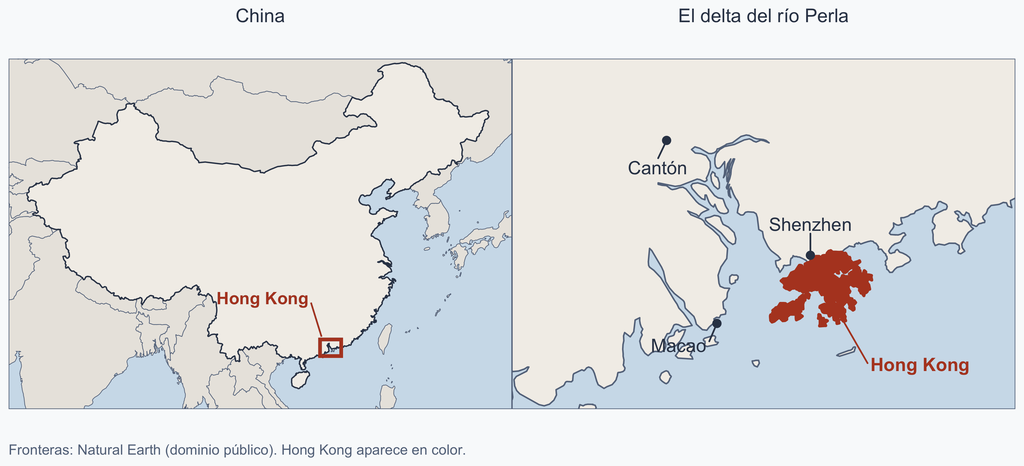

## Dos historias, una misma costa

|  | **Hong Kong** | **China continental** |
| --- | --- | --- |
| 1842 | Cedida a Gran Bretaña tras la Primera Guerra del Opio | Imperio Qing |
| 1949 | Todavía colonia británica | Se funda la República Popular |
| **1974** | **Se crea la Comisión Independiente Contra la Corrupción (ICAC), bajo dominio británico** |  |
| 1978 |  | Comienza la reforma y apertura |
| 1997 | Devuelta a China | “Un país, dos sistemas” |

La reforma que vamos a estudiar la hizo un gobierno colonial, veintitrés años antes de la devolución. “El mismo país” es la forma equivocada de pensar esta comparación.

Fecha de fundación: ICAC, *History of the ICAC*.

## Hong Kong antes de la ICAC

- Las ambulancias pedían “dinero para el té” antes de recoger a un enfermo
- En el hospital, una propina te conseguía un cómodo o un vaso de agua
- A los bomberos se les pagaba dos veces: una por abrir la manguera y otra por cerrarla
- Nada de esto era por libre. La policía lo operaba como negocio — corrupción *sindicada*: precios fijos, cobros con calendario y reparto hacia arriba en el escalafón
- En junio de 1973 un oficial británico de alto rango de la policía de Hong Kong voló a casa
- Se fue días antes de ser interrogado por más de 4 millones de dólares de Hong Kong que no podía explicar
- La propia unidad anticorrupción de la policía llevaba dos años investigándolo, sin llegar a nada
- Hubo marchas, y luego una investigación pública
- En febrero de 1974 el gobierno creó una agencia fuera de la policía

El oficial era Peter Godber; fue extraditado en 1975 y encarcelado. Fuentes: Manion (2004), cap. 2; ICAC, historia oficial de la comisión.

## Una agencia colocada fuera de la policía

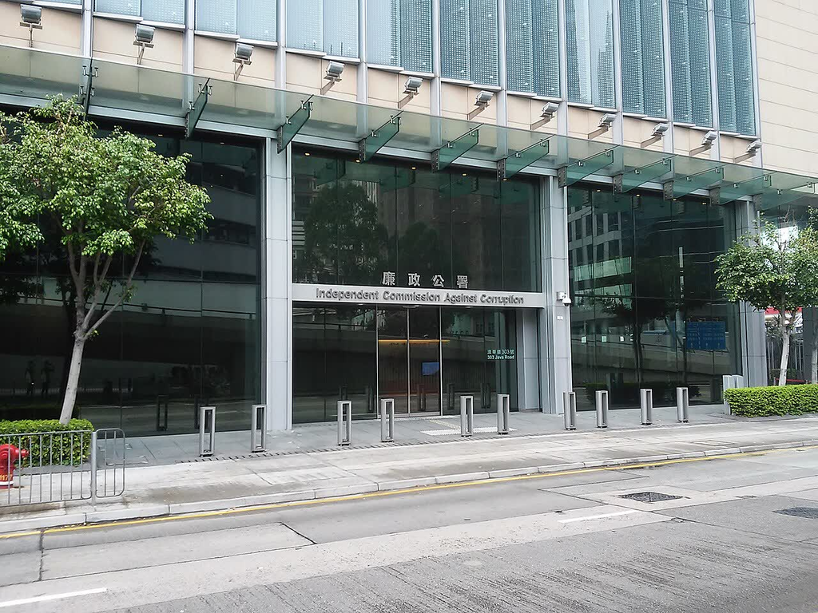

Sede de la ICAC, North Point, Hong Kong. Foto: Citobun, CC BY-SA 4.0, vía Wikimedia Commons. El comisionado responde solo ante el Jefe del Ejecutivo, y ante el Gobernador antes de 1997 — no ante la policía ni ante un ministerio.

## La idea clave de Manion: la corrupción es un equilibrio

```
%%{init: {"fontSize": 22, "htmlLabels": false, "flowchart": {"useMaxWidth": true, "nodeSpacing": 45, "rankSpacing": 55, "htmlLabels": false, "padding": 14, "curve": "basis"}, "themeVariables": {"fontSize": "22px", "fontFamily": "DM Sans, Segoe UI, sans-serif", "primaryColor": "#eef2f5", "primaryText…
flowchart LR
  A["Todos esperan que<br/>los funcionarios<br/>acepten sobornos"] --> B["Para el ciudadano,<br/>pagar es la<br/>opción sensata"]
  A --> C["Para el funcionario,<br/>negarse cuesta<br/>dinero y confianza"]
  B --> D["Casi todos<br/>participan"]
  C --> D
  D -- "unas cuantas detenciones<br/>no cambian nada" --> A
  classDef start fill:#f6e7df,stroke:#b44527,stroke-width:2px,color:#1e293b;
  class A start;
  linkStyle 4 stroke:#b44527,stroke-width:3px;
```

Ilustración del autor sobre Manion (2004). Lo que sostiene el circuito son las creencias sobre qué tan común es la corrupción.

## La ICAC ataca el circuito en tres puntos

```
%%{init: {"fontSize": 22, "htmlLabels": false, "flowchart": {"useMaxWidth": true, "nodeSpacing": 40, "rankSpacing": 55, "htmlLabels": false, "padding": 14, "curve": "basis"}, "themeVariables": {"fontSize": "22px", "fontFamily": "DM Sans, Segoe UI, sans-serif", "primaryColor": "#e7efec", "primaryText…
flowchart LR
  I["ICAC<br/>1974"] --> O["Disuasión:<br/>investigar<br/>y procesar"]
  I --> P["Prevención:<br/>rediseñar<br/>procedimientos"]
  I --> C["Educación:<br/>persuadir y<br/>recibir denuncias"]
  O --> R1["Eleva el riesgo<br/>de aceptar"]
  P --> R2["Elimina la<br/>oportunidad"]
  C --> R3["Cambia lo que<br/>la gente espera"]
  R1 --> N["Lo limpio pasa a ser<br/>lo normal"]
  R2 --> N
  R3 --> N
  classDef goal fill:#e7efec,stroke:#4a7c6f,stroke-width:3px,color:#1e293b;
  class N goal;
```

Rediseñar procedimientos es la jugada estadounidense — uno de tres, nunca el principal.

Ilustración del autor. Manion (2004), cap. 2: la reforma necesita los tres brazos juntos.

## ▶ Hong Kong — la ICAC, 40 años después

[video not shown]

1. La ICAC se apoya en disuasión, prevención y educación. Las dos primeras son obvias. ¿Por qué educación?  
2. En 1973 aceptar un soborno era seguro; hoy la ICAC vende tazas que bromean con eso. ¿Por qué puede venderlas?  
3. La televisora estatal china lo hizo en 2014, en plena campaña de Xi. ¿Por qué entonces, y qué pedirían para creerlo?

CCTV News (hoy CGTN) — ICAC, 40.º aniversario, Hong Kong, 2014. Se reproduce 0:00-2:52.

## ▶ Hong Kong — resuelto

1. **¿Por qué educación?**
   - El circuito se sostiene porque todos esperan que los demás paguen
   - Las detenciones mueven esa expectativa solo si la gente se entera
   - La educación es lo que convierte un proceso penal en una expectativa
   - Los tres brazos funcionan como uno
2. **Por qué hoy se puede vender el chiste**
   - Ya nadie duda de la amenaza que hay detrás
   - Ser citado tiene que ser real y rutinario antes de poder dar risa
   - La jornada de puertas abiertas no es un descanso del trabajo — *es* el brazo educativo
3. **Leer la fuente**
   - El ranking es un índice de *percepciones*, con todos los problemas de la Parte I
   - No hay contrafactual: ¿qué más cambió en Hong Kong después de 1974?
   - Una televisora continental en 2014 tenía sus propias razones para contar esta historia — téngalo presente para la Parte IV

El segmento histórico de este reportaje (2:52-4:36) cubre a Godber y el problema salarial de los años sesenta.

## Hacer creíble la nueva expectativa

- **Independencia.** El comisionado respondía directamente ante el Gobernador, no ante la policía
- **Permanencia.** Una agencia estable, con personal y presupuesto propios
- **Visibilidad.** Altos mandos procesados, en público y de forma repetida
- **Una raya sobre el pasado.** Protesta policial en octubre de 1977
- Amnistía parcial: no se perseguirían los delitos cometidos antes del 1 de enero de 1977
- Quedaron excluidos los ya investigados, los buscados y los que estaban en el extranjero

Fuentes: Manion (2004), cap. 2; historia oficial de la ICAC. La amnistía cerró el pasado una vez — no de forma repetida.

## Dos rutas hacia un gobierno limpio

La Sesión 6 terminó con una frase que vale la pena repetir: *Estados Unidos no se volvió más limpio porque llegara mejor gente — se volvió más limpio porque había **menos que vender**.*

|  | **Estados Unidos (Sesión 6)** | **Hong Kong (desde 1974)** |
| --- | --- | --- |
| El problema | **Sistemática**: el privilegio compraba poder político | **Venal**: el cargo se vendía en efectivo, a precios fijos |
| La solución | Quitar lo que los políticos tenían para vender | Hacer creíbles el castigo y la negativa |
| En la práctica | Cualquiera podía constituir una empresa, sin favor político | Una agencia, fuera de la policía |
| Qué cambió | La **oportunidad** | La **expectativa** |
| Cuánto tardó | Unos cincuenta años, nunca del todo | Visible en una década |

Hong Kong no podía quitar la discrecionalidad — no se puede abolir a la policía. Así que trabajó sobre la expectativa. **Si no puedes quitar la tentación, ¿puedes aun así cambiar lo que la gente espera?**

Fuentes: Manion (2004), cap. 6; Wallis (2006), p. 50, en Glaeser y Goldin, eds., *Corruption and Reform*.

## Cincuenta años después, la brecha sigue visible

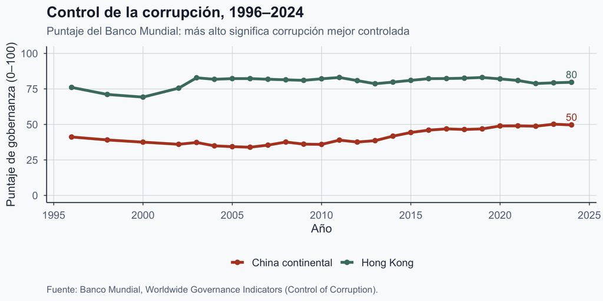

## ¿Pero de verdad fue la ICAC?

- La ICAC llegó en medio de un esfuerzo de reforma mucho más amplio
- Hong Kong era pequeño, rico y urbano, no un continente
- El alza de los ingresos encareció perder un empleo en el servicio público
- Los tribunales y los periódicos operaban con independencia real
- Manion muestra que el diseño era coherente; no puede aleatorizarlo
- Lean Hong Kong como un caso fuerte, no como un experimento controlado

Fuentes: Manion (2004), cap. 2; historia oficial de la ICAC. Estas explicaciones rivales no se ponen a prueba aquí — ese es justo el punto.

## Ejercicio 2 — ¿Funcionaría aquí una ICAC?

**En parejas.**

Mañana su país anuncia una nueva comisión anticorrupción.

1. Nombren **una** característica de diseño de Hong Kong que copiarían, y digan qué cambia.
2. Nombren **una** razón por la que podría fracasar donde ustedes viven.

## ¿Y entonces?

> La respuesta de Manion para Hong Kong: no castigó *más fuerte*. Hizo que el castigo fuera **creíble**, y diseñó a partir de ahí.

Ese es su argumento, y la evidencia es un caso bien documentado, no un experimento. Lo que establece es un **mecanismo**: las expectativas pueden moverse deliberadamente, y mantenerse creíbles.

China continental también castiga la corrupción — con dureza y de forma muy pública.

# Parte IV — Campañas y selectividad

## Dos diseños, lado a lado

Dos diseños institucionales para combatir la corrupción.

| Rasgo de diseño | ICAC de Hong Kong (desde 1974) | China continental (CCDI) |
| --- | --- | --- |
| Quién investiga | Agencia permanente fuera de la policía | Órgano disciplinario del propio Partido |
| Responde ante | El Gobernador, después el Jefe del Ejecutivo | La dirigencia del Partido |
| A quién puede investigar | Sector público **y** privado | Militantes y empleados públicos |
| Ritmo de aplicación | Continuo, rutinario | Por oleadas y campañas |
| Palanca principal | Las expectativas cotidianas | La disciplina y la lealtad |

Fuentes: Manion (2004), caps. 5–6; CCDI. Desde 2018 una Comisión Nacional de Supervisión extiende el alcance continental a todos los empleados públicos. **Cuidado:** estos órganos están dentro de sistemas políticos muy distintos. Es una comparación estructurada, no un experimento controlado.

## La campaña de Xi: real, y muy grande

- Lanzada tras el 18.º Congreso del Partido, noviembre de 2012
- Lema: “tigres y moscas” — altos dirigentes y funcionarios locales por igual
- Zhou Yongkang, exmiembro del Comité Permanente del Politburó, condenado a cadena perpetua
- CCDI: 4.39 millones de casos investigados, 4.7 millones de personas sancionadas
- Ese conteo va de noviembre de 2012 a abril de 2022
- Nadie discute la escala. La pregunta es qué cambió.

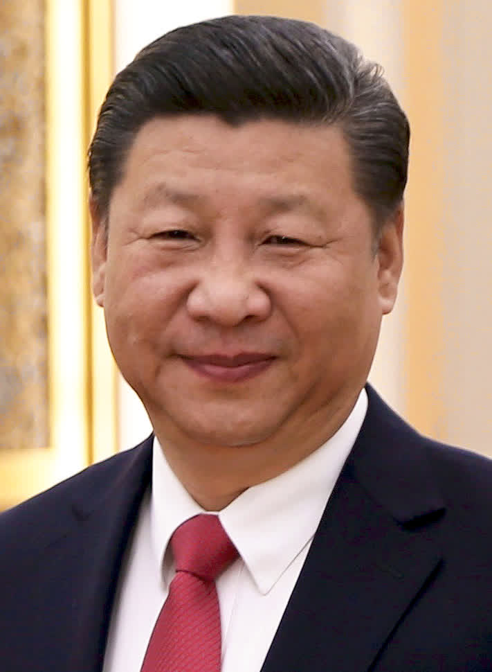

Xi Jinping, marzo de 2017. Departamento de Estado de EE. UU.; dominio público.

Fuentes: conferencia de prensa de la CCDI, junio de 2022 (según lo reportado); sentencia judicial en el caso Zhou Yongkang, 11 de junio de 2015.

## Cuánto valía una conexión política

**El trato de Diego, muchas veces.** Nadie puede observar un reparto secreto de ganancias. Pero el Estado registra cada venta de suelo, y Chen y Kung pueden saber qué compradores estaban ligados a las familias de miembros del Politburó — los “príncipes rojos”. El favoritismo aparece en el precio, sin que nadie tenga que confesar.

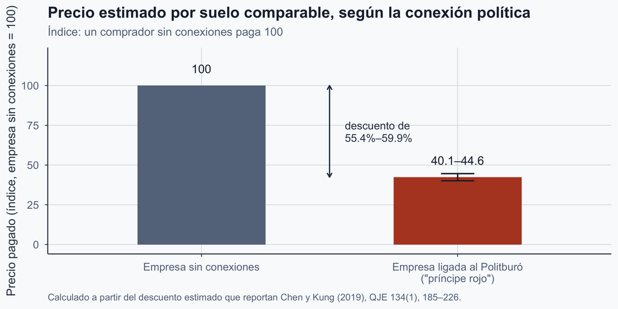

El desarrollador en la puerta decía *nosotros habríamos ofrecido más a la ciudad*. Las empresas conectadas pagaron mucho menos por suelo comparable — evidencia que encaja con su queja, no una medición de la oferta que nunca hizo.

Fuente: Chen y Kung (2019), *Quarterly Journal of Economics*; más de un millón de transacciones, 2004–2016. Los precios los registra el Estado, no se autoinforman en una encuesta.

## ¿Por qué un funcionario daría ese descuento?

**El comprador no es un desconocido.** Una empresa de “príncipes rojos” pertenece a la familia de un miembro del Politburó: un hijo, un yerno.

- En China nadie es dueño del suelo urbano: lo es el **Estado**, desde 1982
- Lo que se vende es un **derecho de uso** de 40 a 70 años, que otorga el gobierno local
- Un terreno vale **100 millones de dólares**; la empresa paga unos **42 millones**
- Sus dueños se vuelven **58 millones** más ricos, de inmediato
- Esos dueños son los hijos de un dirigente nacional
- Ese dirigente se sienta donde se deciden los ascensos a cargos nacionales

**Así, el secretario le paga un soborno a quien puede ascenderlo: en suelo, a los hijos de ese hombre, en vez de en efectivo al hombre.**

Y es negable. Un maletín de efectivo es un delito; una venta de suelo es una decisión de gobierno que parece política pública. Nadie confiesa: el favor aparece en el precio.

Cifras ilustrativas, con el punto medio del descuento estimado por Chen y Kung (2019). El suelo urbano es propiedad del Estado desde la Constitución de 1982; los plazos del derecho de uso los fija el reglamento de 1990.

## Una aplicación real, y también selectiva

**¿La campaña cambió algo?** Chen y Kung observan los mismos precios del suelo antes y después de 2012.

- Una provincia quedaba “alcanzada” cuando llegaba un equipo central de inspección, o cuando Xi nombraba a su nuevo secretario del Partido
- En esas provincias el descuento de los príncipes rojos se redujo entre un tercio y dos quintos
- Los príncipes rojos seguían pagando menos que los demás, pero mucho más cerca del precio ordinario — así que la aplicación fue real
- Antes de 2012, repartir esos descuentos convenía para la carrera: los secretarios del Partido que los otorgaban tenían 23.4% más probabilidades de llegar a un cargo nacional
- Después de 2012 esa ruta se cerró

Real, entonces — pero dirigida. El centro elegía qué provincias inspeccionar. Cuidado: eso muestra una aplicación dirigida a **lugares**, no una prueba de que haya perdonado a los aliados de la dirigencia.

Fuente: Chen y Kung (2019), *Quarterly Journal of Economics*, 134(1), 185–226. La corrupción, medida con ese descuento, cayó entre 31.5% y 42.6% en las provincias que alcanzó la campaña.

## ¿Y entonces? Cinco cosas para llevarse

- Pregunten qué tipo de corrupción tiene un país, no solo cuánta
- El dinero de acceso puede convivir con el crecimiento; el robo y la extorsión no
- La cuenta llega igual: el mejor constructor pierde, y a la ciudad le pagan de menos
- La corrupción dura porque la gente la espera, y en 1973 nadie podía negarse solo
- El gobierno limpio vino de cambiar la estructura, no de esforzarse más

**Para llevar:** la corrupción es un equilibrio. Se rompe cambiando **qué está en venta** (Estados Unidos) o **lo que la gente espera** (Hong Kong). Una campaña sube el castigo sin hacer ninguna de las dos — real mientras dura.

Y hay que tener cuidado en ambas direcciones: el auge de China no prueba que la corrupción ayudara, y el historial de Hong Kong no prueba que la ICAC lo haya hecho sola.

## Referencias

Ang, Y. Y. (2020). *China’s gilded age: The paradox of economic boom and vast corruption*. Cambridge University Press.

Chen, T., & Kung, J. K.-S. (2019). Busting the “princelings”: The campaign against corruption in China’s primary land market. *The Quarterly Journal of Economics, 134*(1), 185–226. https://doi.org/10.1093/qje/qjy027

Glaeser, E. L., & Goldin, C. (2006). Corruption and reform: An introduction. In E. L. Glaeser & C. Goldin (Eds.), *Corruption and reform: Lessons from America’s economic history* (pp. 3–22). University of Chicago Press.

*Global Times*. (2022, June 30). *China punishes 4.7 million people in decade-long anti-graft campaign*. https://www.globaltimes.cn/page/202206/1269498.shtml

## Referencias (continuación)

Independent Commission Against Corruption. (n.d.). *History of the ICAC*. Government of the Hong Kong Special Administrative Region. https://www.icac.org.hk/en/about/history/index.html

Manion, M. (2004). *Corruption by design: Building clean government in mainland China and Hong Kong*. Harvard University Press.

Wallis, J. J. (2006). The concept of systematic corruption in American history. In E. L. Glaeser & C. Goldin (Eds.), *Corruption and reform: Lessons from America’s economic history* (pp. 23–62). University of Chicago Press.

Wedeman, A. (2012). *Double paradox: Rapid growth and rising corruption in China*. Cornell University Press.